# Xenobiotics modify vertical energy transfer from photoautotrophic biofilms to grazers

## 5.4 Boxplot dry weight snails

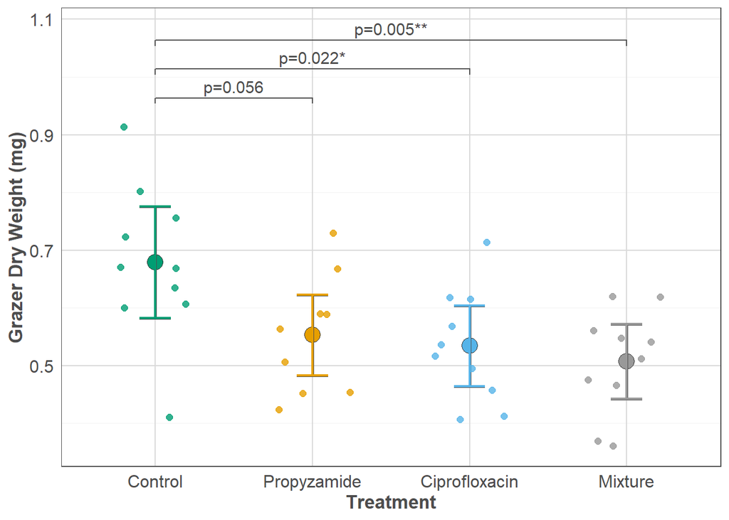

```r
# Plot
snails_boxplot <-
  ggplot(data = filtered_dry_weight,
         mapping = aes(x = factor(
           treatment, levels = c("NC", "Pro", "Cip", "Mix")
         ), y = dryweight_mg)) +
  # Mean
  stat_summary(
    fun = mean,
    geom = "point",
    aes(fill = treatment),
    shape = 21,
    size = 5,
    color = "grey20",
    stroke = 0.5
  ) +

  # 95% CI
  # Black outline (thicker, underneath)
  stat_summary(
    fun.data = mean_cl_normal,
    geom = "errorbar",
    aes(group = treatment),
    width = 0.2,
    linewidth = 1,
    color = "grey30"
  ) +

  # Colored CI on top
  stat_summary(
    fun.data = mean_cl_normal,
    geom = "errorbar",
    aes(color = treatment),
    width = 0.2,
    linewidth = 0.8
  ) +

  # Jittered
geom_point(
  aes(color = treatment),
  position = position_jitter(width = 0.25, height = 0),
  alpha = 0.8,
  size = 2
) +

  # Color scales
  scale_fill_manual(values = c(
    "NC" = "#009E73",
    "Pro" = "#E69F00",
    "Cip" = "#56B4E9",
    "Mix" = "#999999"
  )) +
  scale_color_manual(values = c(
    "NC" = "#009E73",
    "Pro" = "#E69F00",
    "Cip" = "#56B4E9",
    "Mix" = "#999999"
  )) +
  guides(fill = "none") +

  # Theme and labels
  labs(x = "Treatment", y = "Grazer Dry Weight (mg)", color = "") +
  scale_x_discrete(labels = c("Control", "Propyzamide", "Ciprofloxacin", "Mixture")) +
  theme_minimal(base_size = 11) +
  theme(
    legend.position = "none",
    panel.background = element_rect(fill = "grey100"),
    axis.title = element_text(
      size = 13,
      face = "bold",
      colour = "grey30"
    ),
    axis.text.x = element_text(size = 12),
    axis.text.y = element_text(size = 12),
    panel.border = element_rect(fill = NA, colour = "grey30"),
    panel.grid.major = element_line(colour = "grey85", size = 0.4),
    panel.grid.minor = element_line(colour = "grey95", size = 0.2)
  ) +
  # Significance annotations
  annotate(
    "text",
    x = 1.5,
    y = max(filtered_dry_weight$dryweight_mg) + 0.07,
    label = "p=0.056",
    size = 4,
    color = "grey30"
  ) +
  geom_segment(
    aes(
      x = 1,
      xend = 2,
      y = max(dryweight_mg) + 0.05,
      yend = max(dryweight_mg) + 0.05
    ),
    lineend = "round",
    linewidth = 0.5,
    color = "grey30"
  ) +
  # Vertical tick on the left
  geom_segment(
    aes(
      x = 1,
      xend = 1,
      y = max(dryweight_mg) + 0.04,
      yend = max(dryweight_mg) + 0.05
    ),
    color = "grey30",
    linewidth = 0.5
  ) +
  # # Vertical tick on the right
  geom_segment(
    aes(
      x = 2,
      xend = 2,
      y = max(dryweight_mg) + 0.04,
      yend = max(dryweight_mg) + 0.05
    ),
    color = "grey30",
    linewidth = 0.5
  ) +
  annotate(
    "text",
    x = 2.5,
    y = max(filtered_dry_weight$dryweight_mg) + 0.17,
    label = "p=0.005**",
    size = 4,
    color = "grey30"
  ) +
  geom_segment(
    aes(
      x = 1,
      xend = 4,
      y = max(dryweight_mg) + 0.15,
      yend = max(dryweight_mg) + 0.15
    ),
    lineend = "round",
    linewidth = 0.5,
    color = "grey30"
  ) +
  geom_segment(
    aes(
      x = 1,
      xend = 1,
      y = max(dryweight_mg) + 0.14,
      yend = max(dryweight_mg) + 0.15
    ),
    color = "grey30",
    linewidth = 0.5
  ) +
  geom_segment(
    aes(
      x = 4,
      xend = 4,
      y = max(dryweight_mg) + 0.14,
      yend = max(dryweight_mg) + 0.15
    ),
    color = "grey30",
    linewidth = 0.5
  ) +
  annotate(
    "text",
    x = 2,
    y = max(filtered_dry_weight$dryweight_mg) + 0.12,
    label = "p=0.022*",
    size = 4,
    color = "grey30"
  ) +
  geom_segment(
    aes(
      x = 1,
      xend = 3,
      y = max(dryweight_mg) + 0.1,
      yend = max(dryweight_mg) + 0.1
    ),
    lineend = "round",
    linewidth = 0.5,
    color = "grey30"
  ) +
  geom_segment(
    aes(
      x = 1,
      xend = 1,
      y = max(dryweight_mg) + 0.09,
      yend = max(dryweight_mg) + 0.1
    ),
    color = "grey30",
    linewidth = 0.5
  ) +
  geom_segment(
    aes(
      x = 3,
      xend = 3,
      y = max(dryweight_mg) + 0.09,
      yend = max(dryweight_mg) + 0.1
    ),
    color = "grey30",
    linewidth = 0.5
  )


snails_boxplot
```

```r
# save the plot
ggsave(
  "output/snails_boxplot.png",
  width = 16.5,
  height = 12,
  units = "cm",
  dpi = 600
)
```

# 6 Feeding rate snails

- NA’s due to missing snail and zero values of feeding rate due to no measurable feeding in respective week
- Unit feeding rate: µg / day
- Column “used_for_FA_analysis” highlights the ten snails used for FA analyses for each treatment

```r
# insert data
afdw_feeding_rate <-
  read.table(file.path("data\\feeding_assay_afdw_feeding_rate.txt"),
             header = TRUE, sep = "\t")

View(afdw_feeding_rate)
```

## 6.1 Feeding rate snails

#### 6.1.0.1 Histogram feeding rate

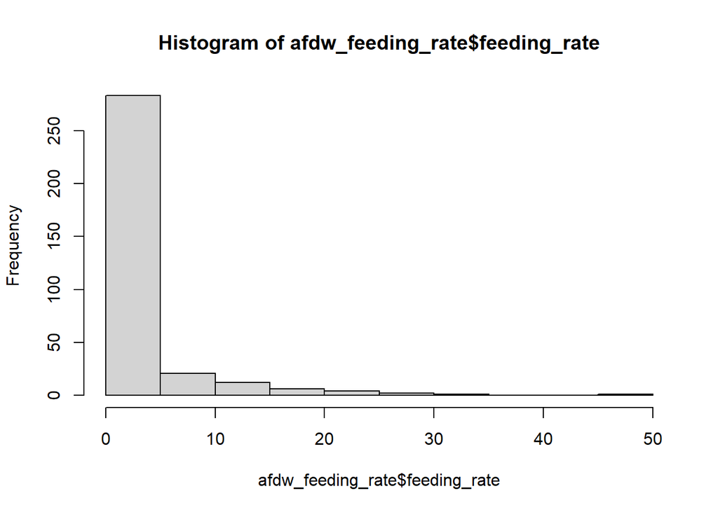

```r
hist(afdw_feeding_rate $ feeding_rate)
```

```r
skewness(afdw_feeding_rate $ feeding_rate, na.rm = TRUE) # skewness > 3
```

```
[1] 3.865973
```

```r
shapiro.test(afdw_feeding_rate $ feeding_rate) # not normal distributed
```

```
    Shapiro-Wilk normality test

data:  afdw_feeding_rate$feeding_rate
W = 0.54728, p-value < 2.2e-16
```

```r
# following visual observation of absolute data & histogram, check for outliers
```

Outlier check:

```r
#Run function one time, after that you can use the shortcut outlierKD (your subset, variable)
outlierKD_feeding_rate <- function(dt, id_col = "treatment", start_col = 6, end_col = 6) {
  # Initialize an empty list to store results for each column
  outlier_results <- list()


  for (i in start_col:end_col) {
    col_name <- colnames(dt)[i]  # Get the column name

    # Extract the column values
    var_name <- dt[[col_name]]

    # Check if the column is numeric
    if (is.numeric(var_name)) {
      na1 <- sum(is.na(var_name))
      m1 <- mean(var_name, na.rm = TRUE)

      # Identify outliers using boxplot stats
      outlier <- boxplot.stats(var_name)$out

      # Find rows with outliers
      outlier_rows <- which(var_name %in% outlier)

      # If no outliers, skip the rest of the loop
      if (length(outlier_rows) == 0) next

      # Get replicate values for the outliers
      id_values <- dt[[id_col]][outlier_rows]

      # Mean of outliers
      mo <- mean(outlier)

      # Collect the outlier information for this column
      outlier_results[[col_name]] <- data.frame(
        Column = col_name,
        Row = outlier_rows,
        Replicate = id_values,
        Outlier = outlier
      )

      cat("\nOutliers for column:", col_name, "\n")
      cat("Outliers identified:", length(outlier), "\n")
      cat("Proportion (%) of outliers:",
          round(length(outlier) / sum(!is.na(var_name)) * 100, 1), "\n")
      cat("Mean of the outliers:", round(mo, 2), "\n")
      cat("Mean with outliers:", round(m1, 2), "\n")
    }
  }

  # Combine all outlier information into one data frame
  if (length(outlier_results) > 0) {
    combined_outliers <- do.call(rbind, outlier_results)
  } else {
    combined_outliers <- data.frame()  # If no outliers were found, return an empty data frame
  }

  # Return combined data frame with outliers information
  return(combined_outliers)
}

# Call the function and store the results
outlier_info_combined_feeding_rate <- outlierKD_feeding_rate(afdw_feeding_rate, id_col = "treatment", start_col = 5, end_col = 5)
```

```
Outliers for column: feeding_rate
Outliers identified: 38
Proportion (%) of outliers: 11.5
Mean of the outliers: 14.87
Mean with outliers: 3.05
```

```r
# Print the combined outlier information
print(outlier_info_combined_feeding_rate)
```

```
                      Column Row Replicate   Outlier
feeding_rate.1  feeding_rate  23        NC 45.410863
feeding_rate.2  feeding_rate  26        NC 31.850622
feeding_rate.3  feeding_rate  28        NC  9.967544
feeding_rate.4  feeding_rate  33       Pro 12.372582
feeding_rate.5  feeding_rate  34       Pro 23.202522
feeding_rate.6  feeding_rate  35       Pro 16.320830
feeding_rate.7  feeding_rate  36       Pro 26.784835
feeding_rate.8  feeding_rate  37       Pro 11.390999
feeding_rate.9  feeding_rate  38       Pro 15.479254
feeding_rate.10 feeding_rate  39       Pro 17.581940
feeding_rate.11 feeding_rate  40       Pro 23.552156
feeding_rate.12 feeding_rate  42       Pro 25.109351
feeding_rate.13 feeding_rate  43       Pro 13.411997
feeding_rate.14 feeding_rate  44       Pro 15.941264
feeding_rate.15 feeding_rate  45       Pro 13.484484
feeding_rate.16 feeding_rate  47       Pro 18.715968
feeding_rate.17 feeding_rate  48       Pro  9.594064
feeding_rate.18 feeding_rate  60       Pro  9.878984
feeding_rate.19 feeding_rate  91       Mix  8.922841
feeding_rate.20 feeding_rate  93       Mix 10.750982
feeding_rate.21 feeding_rate 116       Mix 15.953187
feeding_rate.22 feeding_rate 118       Mix  7.739009
feeding_rate.23 feeding_rate 125        NC 11.963002
feeding_rate.24 feeding_rate 131        NC  7.543135
feeding_rate.25 feeding_rate 132        NC  8.173696
feeding_rate.26 feeding_rate 135        NC  6.728001
feeding_rate.27 feeding_rate 142        NC 11.356729
feeding_rate.28 feeding_rate 144        NC 13.312560
feeding_rate.29 feeding_rate 182       Cip  8.006604
feeding_rate.30 feeding_rate 190       Cip 10.259977
feeding_rate.31 feeding_rate 247        NC  7.966650
feeding_rate.32 feeding_rate 271       Pro 23.456943
feeding_rate.33 feeding_rate 277       Pro  6.978045
feeding_rate.34 feeding_rate 280       Pro 10.906601
feeding_rate.35 feeding_rate 284       Pro 13.300408
feeding_rate.36 feeding_rate 289       Pro 22.166337
feeding_rate.37 feeding_rate 293       Pro  8.206225
feeding_rate.38 feeding_rate 313       Cip 11.233729
```

```r
# Assuming outlier_info_combined is the combined outlier data frame
outlier_info_combined_feeding_rate <- outlier_info_combined_feeding_rate  # If not already assigned

# Count the number of outliers for each replicate
outlier_counts_feeding_rate <- table(outlier_info_combined_feeding_rate$Replicate)

# Convert to a data frame for better readability
outlier_counts_feeding_rate_df <- as.data.frame(outlier_counts_feeding_rate)
colnames(outlier_counts_feeding_rate_df) <- c("Replicate", "Outlier_Count")

View(outlier_counts_feeding_rate_df)
```

Remove outliers:

```r
# Extract the row numbers of the outliers
outlier_rows_feeding_rate <- outlier_info_combined_feeding_rate$Row

# Remove the outlier rows from the dataset
afdw_feeding_rate_cleaned_1 <- afdw_feeding_rate[-outlier_rows_feeding_rate, ]
# 38 outliers identified and removed

# remove NAs
afdw_feeding_rate_cleaned_1 <- na.omit(afdw_feeding_rate_cleaned_1)
# 30 NAs removed
```

Histogram feeding rate again

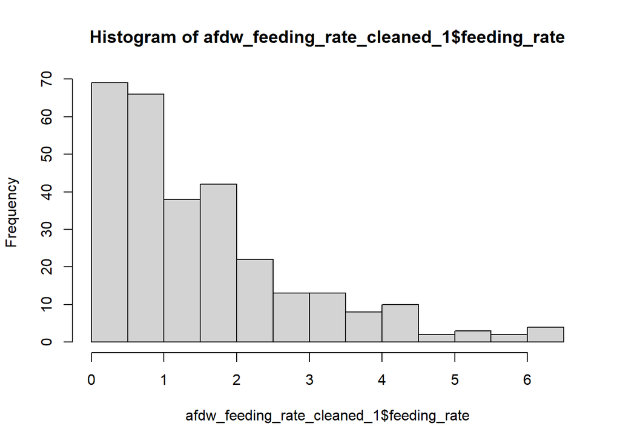

```r
hist(afdw_feeding_rate_cleaned_1 $ feeding_rate)
```

```r
skewness(afdw_feeding_rate_cleaned_1 $ feeding_rate, na.rm = TRUE)
```

```
[1] 1.352644
```

```r
shapiro.test(afdw_feeding_rate_cleaned_1 $ feeding_rate)
```

```
    Shapiro-Wilk normality test

data:  afdw_feeding_rate_cleaned_1$feeding_rate
W = 0.87441, p-value = 1.013e-14
```

Feeding rate still not normal distributed, right skewed but skewness < 1.5, so no data transformation for model.

Calculate mean feeding rate + se + 95 CI for each treatment

```r
mean_feeding_rate <- afdw_feeding_rate_cleaned_1 %>%
  group_by(treatment) %>%
  dplyr::summarize(
    mean_feeding = mean(feeding_rate, na.rm = TRUE),
    n = sum(!is.na(feeding_rate)),
    se = sd(feeding_rate, na.rm = TRUE) / sqrt(n),
    t_crit = qt(0.975, df = n - 1),
    ci_lower = mean_feeding - t_crit * se,
    ci_upper = mean_feeding + t_crit * se,
    .groups = "drop"
  ) %>%
  dplyr::select(treatment, mean_feeding, ci_lower, ci_upper, se)

print(mean_feeding_rate)
```

```
# A tibble: 4 × 5
  treatment mean_feeding ci_lower ci_upper    se
  <chr>            <dbl>    <dbl>    <dbl> <dbl>
1 Cip               1.62    1.26      1.98 0.179
2 Mix               1.20    0.989     1.41 0.106
3 NC                1.76    1.44      2.08 0.161
4 Pro               1.54    1.14      1.93 0.198
```

#### 6.1.0.2 Model feeding rate

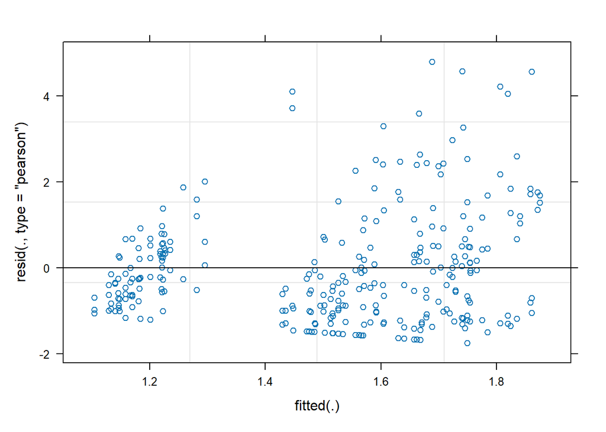

```r
# treatment and beaker as factor
afdw_feeding_rate_cleaned_1 $ treatment <- factor(afdw_feeding_rate_cleaned_1 $ treatment)
afdw_feeding_rate_cleaned_1 $ beaker <- factor(afdw_feeding_rate_cleaned_1 $ beaker)

# response variable: feeding_rate
# fixed effects: treatment
# random effect with constant intercept: (1|beaker)
feeding_rate_lmer <- lmer(feeding_rate ~ treatment + (1|beaker), data = afdw_feeding_rate_cleaned_1)
par(mfrow = c(2, 2))
plot(feeding_rate_lmer)
```

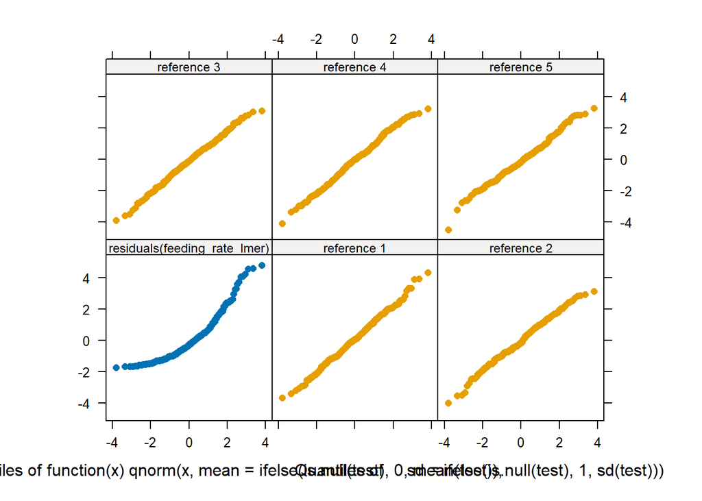

```r
qreference(residuals(feeding_rate_lmer)) # rather S shape
```

```r
pairwise.wilcox.test(afdw_feeding_rate_cleaned_1$feeding_rate,
                     afdw_feeding_rate_cleaned_1$treatment,
                     p.adjust.method = "holm")
```

```
    Pairwise comparisons using Wilcoxon rank sum test with continuity correction

data:  afdw_feeding_rate_cleaned_1$feeding_rate and afdw_feeding_rate_cleaned_1$treatment

    Cip   Mix   NC
Mix 1.000 -     -
NC  1.000 0.059 -
Pro 1.000 1.000 0.738

P value adjustment method: holm
```

```r
# trend NC:Mix p = 0.059
```

Mix vs. Control trend p = 0.059

Ciprofloxacin x propyzamide interaction

```r
afdw_feeding_rate_cleaned_1$Cip <- ifelse(afdw_feeding_rate_cleaned_1$treatment %in% c("Cip", "Mix"),
                                1, 0)

afdw_feeding_rate_cleaned_1$Cip <- factor(afdw_feeding_rate_cleaned_1$Cip, levels = c(0, 1))

afdw_feeding_rate_cleaned_1$Pro <- ifelse(afdw_feeding_rate_cleaned_1$treatment %in% c("Pro", "Mix"),
                                1, 0)

afdw_feeding_rate_cleaned_1$Pro <- factor(afdw_feeding_rate_cleaned_1$Pro, levels = c(0, 1))

# sanity check
table(afdw_feeding_rate_cleaned_1$treatment,
      afdw_feeding_rate_cleaned_1$Cip,
      afdw_feeding_rate_cleaned_1$Pro)
```

```
, ,  = 0


       0  1
  Cip  0 72
  Mix  0  0
  NC  74  0
  Pro  0  0

, ,  = 1


       0  1
  Cip  0  0
  Mix  0 86
  NC   0  0
  Pro 60  0
```

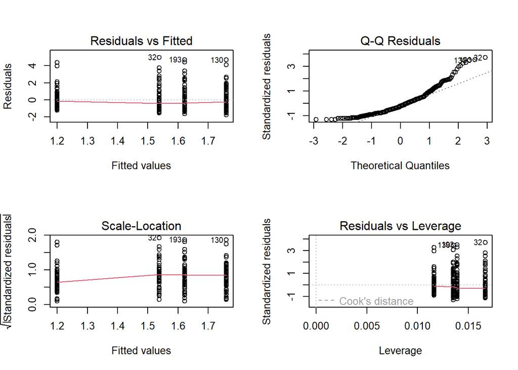

```r
# interaction model
model_feeding_rate_interact <- lm(feeding_rate ~ Cip * Pro, data = afdw_feeding_rate_cleaned_1)
par(mfrow = c(2, 2))
plot(model_feeding_rate_interact) # not normal distributed, S shape
```

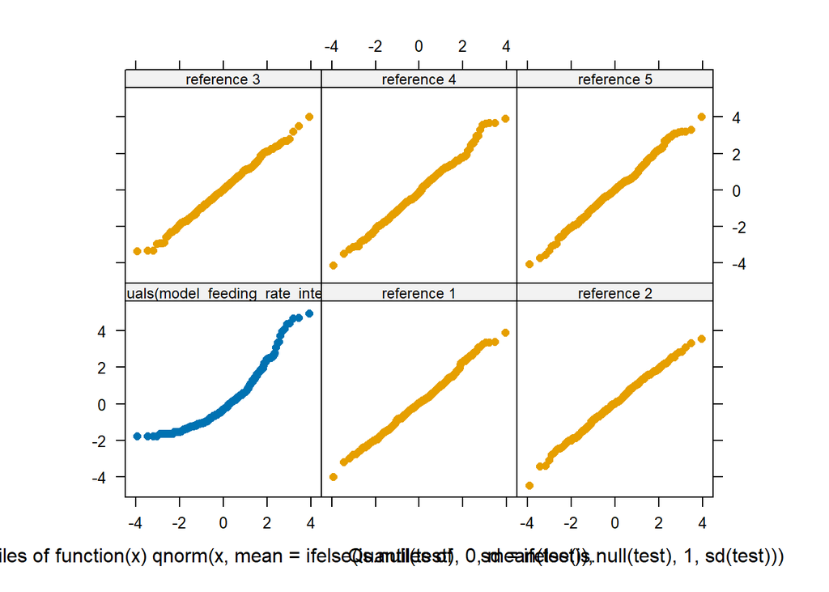

```r
qreference(residuals(model_feeding_rate_interact))
```

```r
kruskal_feeding_rate_interaction <- afdw_feeding_rate_cleaned_1 %>%
  dplyr::mutate(treatment = interaction(Cip, Pro, sep = "_")) %>%
  kruskal.test(feeding_rate ~ treatment, data = .)

kruskal_feeding_rate_interaction
```

```
    Kruskal-Wallis rank sum test

data:  feeding_rate by treatment
Kruskal-Wallis chi-squared = 5.8446, df = 3, p-value = 0.1194
```

#### 6.1.0.3 Boxplot feeding rate

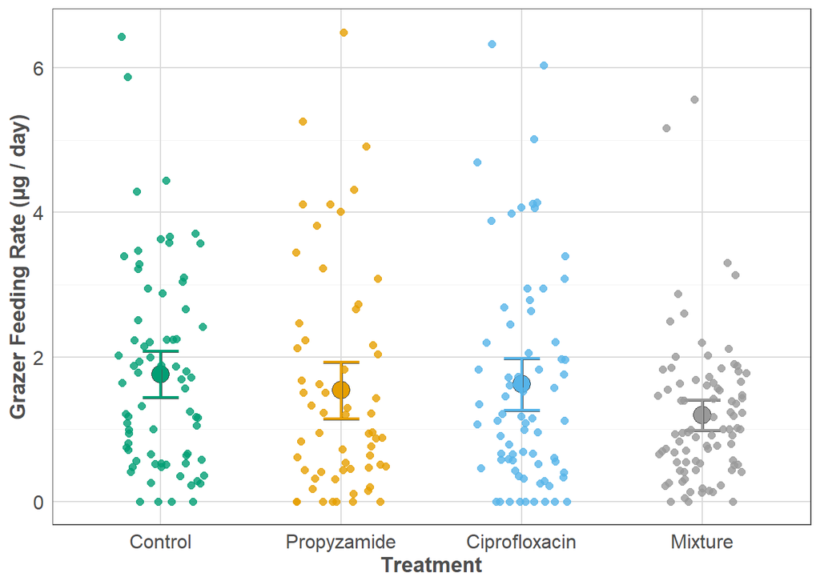

```r
# Plot
feeding_rate_boxplot <-
  ggplot(data = afdw_feeding_rate_cleaned_1,
         mapping = aes(x = factor(
           treatment, levels = c("NC", "Pro", "Cip", "Mix")
         ), y = feeding_rate)) +
  # Mean
  stat_summary(
    fun = mean,
    geom = "point",
    aes(fill = treatment),
    shape = 21,
    size = 5,
    color = "grey20",
    stroke = 0.5
  ) +

  # 95% CI
  # Black outline (thicker, underneath)
  stat_summary(
    fun.data = mean_cl_normal,
    geom = "errorbar",
    aes(group = treatment),
    width = 0.2,
    linewidth = 1,
    color = "grey30"
  ) +

  # Colored CI on top
  stat_summary(
    fun.data = mean_cl_normal,
    geom = "errorbar",
    aes(color = treatment),
    width = 0.2,
    linewidth = 0.8
  ) +

  # Jittered
geom_point(
  aes(color = treatment),
  position = position_jitter(width = 0.25, height = 0),
  alpha = 0.8,
  size = 2
) +

  # Color scales
  scale_fill_manual(values = c(
    "NC" = "#009E73",
    "Pro" = "#E69F00",
    "Cip" = "#56B4E9",
    "Mix" = "#999999"
  )) +
  scale_color_manual(values = c(
    "NC" = "#009E73",
    "Pro" = "#E69F00",
    "Cip" = "#56B4E9",
    "Mix" = "#999999"
  )) +
  guides(fill = "none") +

  # Theme and labels
  labs(x = "Treatment", y = "Grazer Feeding Rate (µg / day)", color = "") +
  scale_x_discrete(labels = c("Control", "Propyzamide", "Ciprofloxacin", "Mixture")) +
  theme_minimal(base_size = 11) +
  theme(
    legend.position = "none",
    panel.background = element_rect(fill = "grey100"),
    axis.title = element_text(
      size = 13,
      face = "bold",
      colour = "grey30"
    ),
    axis.text.x = element_text(size = 12),
    axis.text.y = element_text(size = 12),
    panel.border = element_rect(fill = NA, colour = "grey30"),
    panel.grid.major = element_line(colour = "grey85", size = 0.4),
    panel.grid.minor = element_line(colour = "grey95", size = 0.2)
  )

feeding_rate_boxplot
```

```r
# save the plot
ggsave(
  "output/feeding_rate.png",
  width = 16.5,
  height = 12,
  units = "cm",
  dpi = 600
)
```

# 7 Fatty acid composition snails

Statistics for fatty acid composition of snails in absolute values (µg fatty acid / mg dry weight snail (soft body)).

```r
# insert data
FA_Snails_absolute <-
  read.table(file.path("data\\FA_Snails_absolute.txt"),
             header = TRUE, sep = "\t")

View(FA_Snails_absolute)
# Mix S_29 no data, fatty acid extraction did not work
```

## 7.1 Absolute SAFA, MUFA & PUFA concentrations

1) Total SAFA content

```r
# total SAFA, MUFA, PUFA content; sa = "snail absolute"
# total SAFA content
# filter saturated fatty acids in new table
SAFA_sa <- FA_Snails_absolute %>%
filter(fa %in% c("C08:0", "C10:0", "C11:0", "C12:0", "C13:0", "C14:0", "C15:0", "C16:0", "C18:0", "C20:0", "C21:0", "C22:0", "C24:0"))

# Sum SAFA per replicate and treatment
total_SAFA_per_snail <- SAFA_sa %>%
  dplyr::group_by(replicate, treatment) %>%
  dplyr::summarize(sum_SAFA = sum(fa_conc), .groups = "drop")
print(total_SAFA_per_snail)
```

```
# A tibble: 39 × 3
   replicate treatment sum_SAFA
   <chr>     <chr>        <dbl>
 1 S_1       NC           287.
 2 S_10      NC           102.
 3 S_11      Pro          177.
 4 S_12      Pro          171.
 5 S_13      Pro          131.
 6 S_14      Pro          128.
 7 S_15      Pro           92.6
 8 S_16      Pro          102.
 9 S_17      Pro          128.
10 S_18      Pro          122.
# ℹ 29 more rows
```

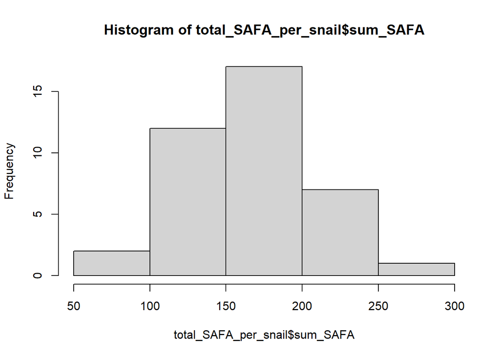

```r
# Statistical differences
hist(total_SAFA_per_snail $ sum_SAFA) # normal distributed
```

```r
shapiro.test(total_SAFA_per_snail $ sum_SAFA) # normal distributed
```

```
    Shapiro-Wilk normality test

data:  total_SAFA_per_snail$sum_SAFA
W = 0.96987, p-value = 0.372
```

```r
leveneTest(sum_SAFA ~ treatment, data = total_SAFA_per_snail) # homogenous
```

```
Levene's Test for Homogeneity of Variance (center = median)
      Df F value Pr(>F)
group  3  0.5795 0.6324
      35
```

```r
anova_SAFA <- aov(sum_SAFA ~ treatment, data = total_SAFA_per_snail)
summary(anova_SAFA)
```

```
            Df Sum Sq Mean Sq F value  Pr(>F)
treatment    3  38898   12966    9.26 0.00012 ***
Residuals   35  49007    1400
---
Signif. codes:  0 '***' 0.001 '**' 0.01 '*' 0.05 '.' 0.1 ' ' 1
```

```r
TukeyHSD(anova_SAFA)
```

```
  Tukey multiple comparisons of means
    95% family-wise confidence level

Fit: aov(formula = sum_SAFA ~ treatment, data = total_SAFA_per_snail)

$treatment
              diff        lwr        upr     p adj
Mix-Cip -74.922274 -121.28987 -28.554679 0.0006092
NC-Cip  -42.670799  -87.80170   2.460105 0.0694651
Pro-Cip -78.088463 -123.21937 -32.957559 0.0002465
NC-Mix   32.251476  -14.11612  78.619072 0.2567096
Pro-Mix  -3.166189  -49.53378  43.201407 0.9977405
Pro-NC  -35.417664  -80.54857   9.713240 0.1677967
```

```r
# Calculate mean, se and 95% CI per treatment
mean_SAFA_sa <- total_SAFA_per_snail %>%
  dplyr::group_by(treatment) %>%
  dplyr::summarize(
    mean_SAFA = mean(sum_SAFA, na.rm = TRUE),
    n = sum(!is.na(sum_SAFA)),
    se = sd(sum_SAFA, na.rm = TRUE) / sqrt(n),
    t_crit = qt(0.975, df = n - 1),
    ci_lower = mean_SAFA - t_crit * se,
    ci_upper = mean_SAFA + t_crit * se,
    .groups = "drop"
  ) %>%
  dplyr::select(treatment, mean_SAFA, ci_lower, ci_upper, se)

# Extract mean of control group for percental difference
control_mean_SAFA_sa <- mean_SAFA_sa %>%
  filter(treatment == "NC") %>%
  pull(mean_SAFA)

# Calculate percental difference from control
mean_SAFA_sa <- mean_SAFA_sa %>%
  mutate(percent_diff_from_NC = 100 * (mean_SAFA - control_mean_SAFA_sa) / control_mean_SAFA_sa)

print(mean_SAFA_sa)
```

```
# A tibble: 4 × 6
  treatment mean_SAFA ci_lower ci_upper    se percent_diff_from_NC
  <chr>         <dbl>    <dbl>    <dbl> <dbl>                <dbl>
1 Cip            215.     197.     233.  7.99                 24.8
2 Mix            140.     110.     170. 13.0                 -18.7
3 NC             172.     136.     208. 16.1                   0
4 Pro            137.     116.     158.  9.34                -20.6
```

2) Total MUFA content

```r
# filter mono-unsaturated fatty acids in new table
MUFA_sa <- FA_Snails_absolute %>%
  filter(fa %in% c("C14:1", "C15:1", "C16:1", "C17:1", "C18:1", "C20:1", "C22:1", "C24:1"))

# Sum MUFA per replicate and treatment
total_MUFA_per_snail <- MUFA_sa %>%
  dplyr::group_by(replicate, treatment) %>%
  dplyr::summarize(sum_MUFA = sum(fa_conc), .groups = "drop")
print(total_MUFA_per_snail)
```

```
# A tibble: 39 × 3
   replicate treatment sum_MUFA
   <chr>     <chr>        <dbl>
 1 S_1       NC           189.
 2 S_10      NC           109.
 3 S_11      Pro          179.
 4 S_12      Pro           33.0
 5 S_13      Pro           55.4
 6 S_14      Pro          143.
 7 S_15      Pro           48.8
 8 S_16      Pro           33.2
 9 S_17      Pro          149.
10 S_18      Pro          140.
# ℹ 29 more rows
```

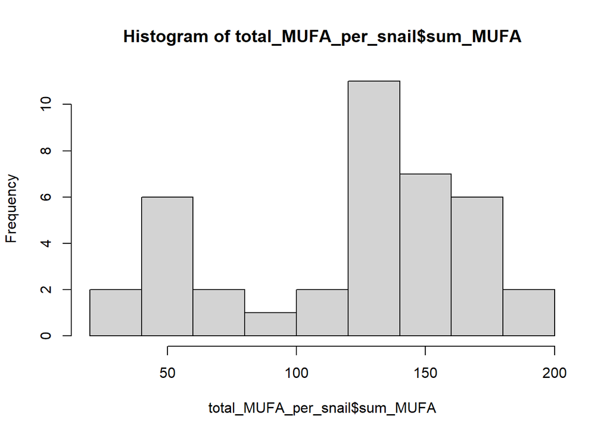

```r
# Statistical differences
hist(total_MUFA_per_snail $ sum_MUFA)
```

```r
shapiro.test(total_MUFA_per_snail $ sum_MUFA)
```

```
    Shapiro-Wilk normality test

data:  total_MUFA_per_snail$sum_MUFA
W = 0.90234, p-value = 0.002577
```

```r
leveneTest(sum_MUFA ~ treatment, data = total_MUFA_per_snail)
```

```
Levene's Test for Homogeneity of Variance (center = median)
      Df F value  Pr(>F)
group  3   3.622 0.02235 *
      35
---
Signif. codes:  0 '***' 0.001 '**' 0.01 '*' 0.05 '.' 0.1 ' ' 1
```

```r
pairwise.wilcox.test(total_MUFA_per_snail$sum_MUFA,
                     total_MUFA_per_snail$treatment,
                     p.adjust.method = "BH")
```

```
    Pairwise comparisons using Wilcoxon rank sum exact test

data:  total_MUFA_per_snail$sum_MUFA and total_MUFA_per_snail$treatment

    Cip    Mix    NC
Mix 0.0063 -      -
NC  0.7394 0.0063 -
Pro 0.5230 0.5230 0.4351

P value adjustment method: BH
```

```r
# Calculate mean, se and 95% CI per treatment
mean_MUFA_sa <- total_MUFA_per_snail %>%
  dplyr::group_by(treatment) %>%
  dplyr::summarize(
    mean_MUFA = mean(sum_MUFA, na.rm = TRUE),
    n = sum(!is.na(sum_MUFA)),
    se = sd(sum_MUFA, na.rm = TRUE) / sqrt(n),
    t_crit = qt(0.975, df = n - 1),
    ci_lower = mean_MUFA - t_crit * se,
    ci_upper = mean_MUFA + t_crit * se,
    .groups = "drop"
  ) %>%
  dplyr::select(treatment, mean_MUFA, ci_lower, ci_upper, se)

# Extract mean of control group for percental difference
control_mean_MUFA_sa <- mean_MUFA_sa %>%
  filter(treatment == "NC") %>%
  pull(mean_MUFA)

# Calculate percental difference from control
mean_MUFA_sa <- mean_MUFA_sa %>%
  mutate(percent_diff_from_NC = 100 * (mean_MUFA - control_mean_MUFA_sa) / control_mean_MUFA_sa)

print(mean_MUFA_sa)
```

```
# A tibble: 4 × 6
  treatment mean_MUFA ci_lower ci_upper    se percent_diff_from_NC
  <chr>         <dbl>    <dbl>    <dbl> <dbl>                <dbl>
1 Cip           143.     127.      158.  6.79                -2.41
2 Mix            77.5     47.6     107. 12.9                -47.1
3 NC            146.     130.      162.  7.07                 0
4 Pro           108.      65.8     150. 18.7                -26.1
```

3) Total PUFA content

```r
# filter poly-unsaturated fatty acids in new table
PUFA_sa <- FA_Snails_absolute %>%
  filter(fa %in% c("C18:2(n-6c)", "C18:2(n-6t)", "C18:3(n-3)", "C18:3(n-6)", "C18:4(n-3)", "C20:2(n-6)", "C20:3(n-6)", "C20:3(n-3)", "C20:4(n-6)", "C20:5(n-3)", "C22:2", "C22:5(n-3)", "C22:6(n-3)"))

# Sum PUFA per replicate and treatment
total_PUFA_per_snail <- PUFA_sa %>%
  dplyr::group_by(replicate, treatment) %>%
  dplyr::summarize(sum_PUFA = sum(fa_conc), .groups = "drop")
print(total_PUFA_per_snail)
```

```
# A tibble: 39 × 3
   replicate treatment sum_PUFA
   <chr>     <chr>        <dbl>
 1 S_1       NC           117.
 2 S_10      NC            58.0
 3 S_11      Pro           68.5
 4 S_12      Pro           62.2
 5 S_13      Pro           39.1
 6 S_14      Pro           45.1
 7 S_15      Pro           44.7
 8 S_16      Pro           51.1
 9 S_17      Pro           68.3
10 S_18      Pro          106.
# ℹ 29 more rows
```

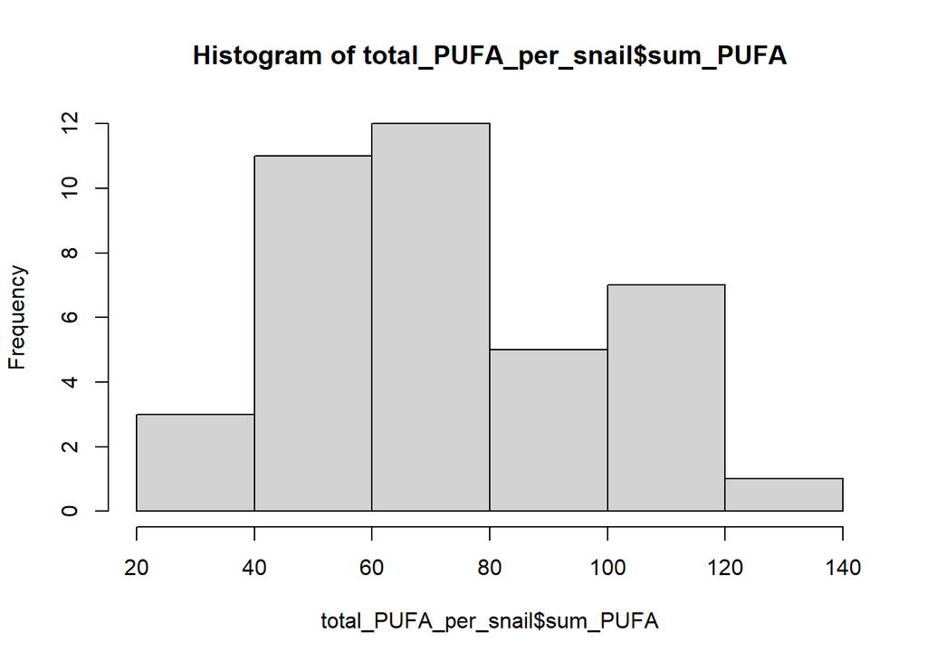

```r
# statistics
hist(total_PUFA_per_snail $ sum_PUFA)
```

```r
shapiro.test(total_PUFA_per_snail $ sum_PUFA)
```

```
    Shapiro-Wilk normality test

data:  total_PUFA_per_snail$sum_PUFA
W = 0.96194, p-value = 0.2068
```

```r
leveneTest(sum_PUFA ~ treatment, data = total_PUFA_per_snail)
```

```
Levene's Test for Homogeneity of Variance (center = median)
      Df F value Pr(>F)
group  3  0.5863  0.628
      35
```

```r
anova_PUFA <- aov(sum_PUFA ~ treatment, data = total_PUFA_per_snail)
summary(anova_PUFA)
```

```
            Df Sum Sq Mean Sq F value   Pr(>F)
treatment    3   9381    3127   7.427 0.000565 ***
Residuals   35  14736     421
---
Signif. codes:  0 '***' 0.001 '**' 0.01 '*' 0.05 '.' 0.1 ' ' 1
```

```r
TukeyHSD(anova_PUFA)
```

```
  Tukey multiple comparisons of means
    95% family-wise confidence level

Fit: aov(formula = sum_PUFA ~ treatment, data = total_PUFA_per_snail)

$treatment
              diff        lwr       upr     p adj
Mix-Cip -20.291696 -45.718032  5.134640 0.1568488
NC-Cip   22.987033  -1.761145 47.735212 0.0765901
Pro-Cip  -6.302387 -31.050565 18.445791 0.9014379
NC-Mix   43.278729  17.852393 68.705065 0.0003083
Pro-Mix  13.989309 -11.437027 39.415645 0.4577808
Pro-NC  -29.289420 -54.037599 -4.541242 0.0150906
```

```r
# Calculate mean, se and 95% CI per treatment
mean_PUFA_sa <- total_PUFA_per_snail %>%
  dplyr::group_by(treatment) %>%
  dplyr::summarize(
    mean_PUFA = mean(sum_PUFA, na.rm = TRUE),
    n = sum(!is.na(sum_PUFA)),
    se = sd(sum_PUFA, na.rm = TRUE) / sqrt(n),
    t_crit = qt(0.975, df = n - 1),
    ci_lower = mean_PUFA - t_crit * se,
    ci_upper = mean_PUFA + t_crit * se,
    .groups = "drop"
  ) %>%
  dplyr::select(treatment, mean_PUFA, ci_lower, ci_upper, se)

# Extract mean of control group for percental difference
control_mean_PUFA_sa <- mean_PUFA_sa %>%
  filter(treatment == "NC") %>%
  pull(mean_PUFA)

# Calculate percental difference from control
mean_PUFA_sa <- mean_PUFA_sa %>%
  mutate(percent_diff_from_NC = 100 * (mean_PUFA - control_mean_PUFA_sa) / control_mean_PUFA_sa)

print(mean_PUFA_sa)
```

```
# A tibble: 4 × 6
  treatment mean_PUFA ci_lower ci_upper    se percent_diff_from_NC
  <chr>         <dbl>    <dbl>    <dbl> <dbl>                <dbl>
1 Cip            72.0     57.3     86.6  6.47                -24.2
2 Mix            51.7     39.7     63.6  5.18                -45.6
3 NC             95.0     78.5    111.   7.27                  0
4 Pro            65.7     50.1     81.3  6.90                -30.8
```

SAFA, MUFA & PUFA relative differences to control plot:

```r
snail_class_abs <- bind_rows(
  prep_class_from_replicates(total_SAFA_per_snail, "sum_SAFA", "SAFA"),
  prep_class_from_replicates(total_MUFA_per_snail, "sum_MUFA", "MUFA"),
  prep_class_from_replicates(total_PUFA_per_snail, "sum_PUFA", "PUFA")
) %>%
  mutate(
    Class = factor(Class, levels = c("SAFA","PUFA","MUFA")),
    treatment = factor(treatment, levels = c("NC","Pro","Cip","Mix"))
  )

snail_class_abs
```

```
# A tibble: 12 × 5
   treatment Class  mean   lwr   upr
   <fct>     <fct> <dbl> <dbl> <dbl>
 1 Cip       SAFA  215.  197.  233.
 2 Mix       SAFA  140.  110.  170.
 3 NC        SAFA  172.  136.  208.
 4 Pro       SAFA  137.  116.  158.
 5 Cip       MUFA  143.  127.  158.
 6 Mix       MUFA   77.5  47.6 107.
 7 NC        MUFA  146.  130.  162.
 8 Pro       MUFA  108.   65.8 150.
 9 Cip       PUFA   72.0  57.3  86.6
10 Mix       PUFA   51.7  39.7  63.6
11 NC        PUFA   95.0  78.5 111.
12 Pro       PUFA   65.7  50.1  81.3
```

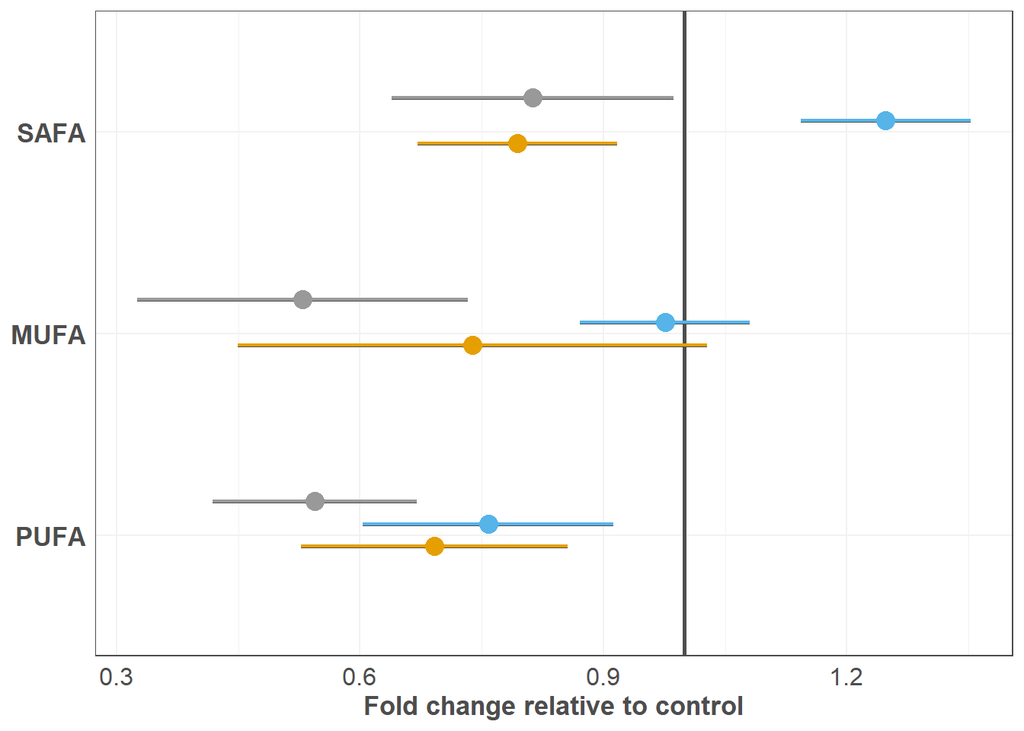

```r
# relative values
snail_class_rel <- snail_class_abs %>%
  group_by(Class) %>%
  mutate(
    ctrl_mean = mean[treatment == "NC"][1],
    mean = mean / ctrl_mean,
    lwr  = lwr  / ctrl_mean,
    upr  = upr  / ctrl_mean
  ) %>%
  ungroup() %>%
  dplyr::select(-ctrl_mean)


plot_df_snails <- snail_class_rel

plot_df_snails <- plot_df_snails %>%
  mutate(
    show = ifelse(treatment == "NC", 0, 1),
    treatment = factor(treatment, levels = c("NC","Pro","Cip","Mix")),
    Class = factor(Class, levels = c("PUFA", "MUFA", "SAFA")),
    lwr = ifelse(lwr < 0, 0, lwr)
  )

# plot
fa_snails_relative_changes <- ggplot(plot_df_snails, aes(x = mean, y = Class)) +
  geom_vline(xintercept = 1,
             linewidth = 1,
             colour = "grey30") +

  # Black CI outline
  geom_errorbarh(
    aes(xmin = lwr, xmax = upr, group = treatment, alpha = show),
    height = 0,
    linewidth = 1,
    colour = "grey30",
    position = position_dodge(width = 0.45)
  ) +

  # Colored CI overlay
  geom_errorbarh(
    aes(xmin = lwr, xmax = upr, colour = treatment, alpha = show),
    height = 0,
    linewidth = 0.8,
    position = position_dodge(width = 0.45)
  ) +

  geom_point(
    aes(colour = treatment, alpha = show),
    size = 4,
    position = position_dodge(width = 0.45)
  ) +

  scale_colour_manual(
    values = c(
    "NC" = "#009E73",
    "Pro" = "#E69F00",
    "Cip" = "#56B4E9",
    "Mix" = "#999999"
    ),
    labels = c(
      "NC"  = "Control",
      "Pro" = "Propyzamide",
      "Cip" = "Ciprofloxacin",
      "Mix" = "Mixture"
    ),
    name = "Treatment"
  ) +
  scale_alpha_identity() +
  guides(
    colour = guide_legend(override.aes = list(alpha = 1))
  ) +

  labs(
    x = "Fold change relative to control",
    y = NULL
  ) +

  theme_minimal(base_size = 11) +
  theme(
    legend.position = "none",
    legend.title = element_text(size = 12, face = "bold", colour = "grey30"),
    legend.text  = element_text(size = 11, colour = "grey30"),
    panel.background = element_rect(fill = "grey100"),
    axis.title = element_text(size = 13, face = "bold", colour = "grey30"),
    axis.text.x = element_text(size = 12),
    axis.text.y = element_text(size = 13, face = "bold", colour = "grey30"),
    panel.border = element_rect(fill = NA, colour = "grey30"),
    panel.grid.major = element_line(colour = "grey95", size = 0.4),
    panel.grid.minor = element_line(colour = "grey95", size = 0.2)
  )

fa_snails_relative_changes
```

```r
# save the plot
ggsave(
  "output/fa_snails_relative_changes.png",
  plot = fa_snails_relative_changes,
  width = 16.5,
  height = 12,
  units = "cm",
  dpi = 600
)
```

4) Total FA per snail

```r
# total FA
total_FA_snails <- bind_rows(total_SAFA_per_snail, total_MUFA_per_snail, total_PUFA_per_snail)

total_FA_per_snail <- total_FA_snails %>%
  dplyr::group_by(replicate, treatment) %>%
  dplyr::summarize(sum_FA = sum(sum_SAFA, sum_MUFA, sum_PUFA, na.rm = TRUE))
print(total_FA_per_snail)
```

```
# A tibble: 39 × 3
# Groups:   replicate [39]
   replicate treatment sum_FA
   <chr>     <chr>      <dbl>
 1 S_1       NC          594.
 2 S_10      NC          269.
 3 S_11      Pro         425.
 4 S_12      Pro         266.
 5 S_13      Pro         225.
 6 S_14      Pro         316.
 7 S_15      Pro         186.
 8 S_16      Pro         187.
 9 S_17      Pro         345.
10 S_18      Pro         368.
# ℹ 29 more rows
```